# EDA_games

**Table of contents**

- Описание работы
- Импорт библиотек и данных
- Изучение структуры данных
- Подготовка данных
- Исследовательская часть
  - **Сколько игр выпускалось в разные годы?**
  - **Как менялись продажи по платформам во времени?**
  - **Выбираю актуальные данные для дальнейшего анализа**
  - **Какие платформы лидируют по продажам, растут или падают?**
  - **Глобальным продажи игр в разбивке по платформам**
  - **Взаимосвязь между оценками (игроки и критики) и общими продажами**
  - **Какие жанры игр продаются больше всех? Выделяются ли жанры с высокими и низкими продажами?**
- Портрет пользователя каждого региона
  - **Самые популярные платформы (топ-5)**
  - **Самые популярные жанры (топ-5)**
  - **Влияет ли рейтинг ESRB на продажи в отдельном регионе?**
- Проверка гипотез
  - **Средние пользовательские рейтинги платформ Xbox One и PC одинаковые?**
  - **Средние пользовательские рейтинги жанров Action и Sports разные?**
- Общий вывод

# Описание работы

**Цель работы** состоит в анализе данных о продажах компьютерных игр для определения успешности их выпуска на различных платформах и в разных регионах.

**Проблема** заключается в том, что необходимо провести исследование и обработку большого объема данных о продажах игр, чтобы выявить закономерности и тенденции, влияющие на успешность игровых платформ и жанров. Это поможет сделать выводы о том, какие платформы и жанры наиболее популярны, а также понять, как отзывы пользователей и критиков влияют на продажи игр.

**Данные** включают в себя продажи игр, жанры, разбитие по регионам, и другую информацию о каждой игре. Датасет содержит следующие переменные:

- Название игры: название конкретной видеоигры.
- Платформа: игровая платформа, на которой была выпущена игра (например, PlayStation, Xbox, PC и т.д.).
- Год выпуска: год, когда игра была выпущена.
- Жанр: категория игры, определяющая ее основную тематику (например, экшн, стратегия, спорт и т.д.).
- Продажи в Северной Америке: общая сумма продаж игры в регионе Северная Америка (в миллионах долларов).
- Продажи в Европе: общая сумма продаж игры в регионе Европа (в миллионах долларов).
- Продажи в Японии: общая сумма продаж игры в регионе Япония (в миллионах долларов).
- Продажи в других регионах: общая сумма продаж игры в остальных регионах, не включенных в Северную Америку, Европу и Японию (в миллионах долларов).
- Оценка критиков: средняя оценка игры, выставленная критиками (от 0 до 100).
- Оценка пользователей: средняя оценка игры, выставленная пользователями (от 0 до 10).
- Рейтинг ESRB: рейтинг игры, присвоенный Entertainment Software Rating Board (ESRB). Рейтинг указывает на возрастные ограничения и содержательные особенности игры.

**Ожидаемые результаты** включают выявление наиболее успешных игровых платформ и жанров, а также оценку влияния отзывов критиков и пользователей на продажи игр. Результаты исследования помогут понять предпочтения игроков и основные факторы, влияющие на коммерческий успех видеоигр.

[figure not shown]

**План работы:**

1) Импорт данных, Изучение структуры данных.

```
1. Осмотреть данные для дальнейшей подготовки
```

2) Подготовка данных

```
1. Помимо изменения названий столбцов на нижний регистр, также рекомендуется проверить наличие пробелов или других символов в названиях столбцов, чтобы облегчить доступ к данным при анализе.
2. При замене значений "tbd" в столбце User_Score на NaN, убедитесь, что столбец User_Score имеет числовой тип данных (float) после замены.
3. При замене значений в столбце Year_of_Release на int, проверьте, что не возникло ошибок или пропущенных значений после преобразования.
```

3) Исследовательская часть

```
1. Для определения актуального периода можно использовать анализ количества выпущенных игр по годам. Обратите внимание на тренды и периоды, когда количество игр сильно увеличивается или уменьшается.
2. При анализе платформ, выбранных с наибольшими суммарными продажами, рекомендуется также оценить их текущую активность на рынке. Учтите, что новые платформы могут появляться и старые платформы могут исчезать.
3. При анализе влияния отзывов пользователей и критиков на продажи, помимо диаграммы рассеяния и корреляции, можно использовать также дополнительные методы, например, разделение выборки на группы с высокими и низкими оценками для дополнительного сравнительного анализа.
```

4) Составьте портрет пользователя каждого региона

```
1. Для анализа различий в долях продаж популярных платформ и жанров в разных регионах, можно использовать не только числовые значения, но и визуализацию данных (например, круговые диаграммы или столбчатые диаграммы).
2. При анализе влияния рейтинга ESRB на продажи в отдельном регионе, помимо описания различий, можно использовать статистические методы (например, t-тест) для проверки гипотезы о наличии статистически значимой связи.
```

5) Проверьте гипотезы:

```
1. При формулировании нулевых и альтернативных гипотез, убедитесь, что они ясно отражают сравниваемые параметры и направление ожидаемого эффекта.
2. При выборе критерия для проверки гипотез, обратите внимание на условия применимости выбранного критерия и учтите особенности данных (например, нормальность распределения).
3. Укажите пороговое значение alpha, которое вы выбрали для проверки гипотез, и обоснуйте свой выбор.
```

6) В общем выводе подведите итоги анализа и ответьте на поставленные в начале работы вопросы. Укажите основные закономерности и тенденции, выявленные в данных, и сделайте релевантные выводы и рекомендации на основе проведенного исследования.

# Импорт библиотек и данных

```python
import pandas as pd
import matplotlib.pyplot as plt
import seaborn as sns
from scipy import stats as st
import numpy as np
```

```python
data = pd.read_csv(r"C:\project_data\games\games.csv")
```

# Изучение структуры данных

```python
# Осмотр
display(data.head(3))
```

|  | Name | Platform | Year_of_Release | Genre | NA_sales | EU_sales | JP_sales | Other_sales | Critic_Score | User_Score | Rating |
| --- | --- | --- | --- | --- | --- | --- | --- | --- | --- | --- | --- |
| 0 | Wii Sports | Wii | 2006.0 | Sports | 41.36 | 28.96 | 3.77 | 8.45 | 76.0 | 8 | E |
| 1 | Super Mario Bros. | NES | 1985.0 | Platform | 29.08 | 3.58 | 6.81 | 0.77 | NaN | NaN | NaN |
| 2 | Mario Kart Wii | Wii | 2008.0 | Racing | 15.68 | 12.76 | 3.79 | 3.29 | 82.0 | 8.3 | E |

```python
# Пропуски
print(data.isna().sum())
```

```
Name                  2
Platform              0
Year_of_Release     269
Genre                 2
NA_sales              0
EU_sales              0
JP_sales              0
Other_sales           0
Critic_Score       8578
User_Score         6701
Rating             6766
dtype: int64
```

```python
# Явные дубликаты
print(data.duplicated().value_counts())
```

```
False    16715
dtype: int64
```

```python
# Проверяю уникальные значения в столбцах Platform и Genre (для поиска неявных дубликатов)
print(data['Platform'].unique())
print(data['Genre'].unique())
```

```
['Wii' 'NES' 'GB' 'DS' 'X360' 'PS3' 'PS2' 'SNES' 'GBA' 'PS4' '3DS' 'N64'
 'PS' 'XB' 'PC' '2600' 'PSP' 'XOne' 'WiiU' 'GC' 'GEN' 'DC' 'PSV' 'SAT'
 'SCD' 'WS' 'NG' 'TG16' '3DO' 'GG' 'PCFX']
['Sports' 'Platform' 'Racing' 'Role-Playing' 'Puzzle' 'Misc' 'Shooter'
 'Simulation' 'Action' 'Fighting' 'Adventure' 'Strategy' nan]
```

```python
# Дубликаты в названиях игр
data['Name'] = data['Name'].str.lower()
print(data.duplicated().value_counts())
```

```
False    16715
dtype: int64
```

**Вывод (Осмотр данных)** - Пропуски: немного есть в столбцах Name, Year_of_Release, Genre. **Нужно удалить строки с пропуском в имени и жанре**. Пропуски в годе релиза оставляю. Много пропусков в оценках и рейтингах игр. С ними пока ничего не буду делать, так как игры с пропускомами можно использовать в отдельных анализах. - Дубликаты явные и неявные: В столбцах Genre и Platform нет. Дубликаты в названиях игр отсутствуют. - Типы данных: **User_Score надо заменть на float, встречается tbd "to be decided", заменю его на NaN. Year_of_Release нужно заменить на int.** - Названия столбцов: **Названия столбцов нужно привести в нижний регистр**

# Подготовка данных

**Названия столбцов нужно привести в нижний регистр**

```python
data.columns = data.columns.str.lower()
print(data.columns)
```

```
Index(['name', 'platform', 'year_of_release', 'genre', 'na_sales', 'eu_sales',
       'jp_sales', 'other_sales', 'critic_score', 'user_score', 'rating'],
      dtype='object')
```

**User_Score надо заменть на float, встречается tbd "to be decided", заменю его на NaN.** tbd меняю на отсутствие оценки, так как пока этой оценки нет

```python
data['user_score'][data['user_score'] == 'tbd'] = 'nan'
data['user_score'] = data['user_score'].astype('float64')
```

**Year_of_Release нужно заменить на int.**

```python
data['year_of_release'] = data['year_of_release'].astype('Int64')
```

**Удалить строки с пропуском в имени и жанре**

```python
data.dropna(subset=['name', 'genre'], inplace=True)
```

**Посчитать суммарные продажи в отдельный столбец**

```python
data['all_sales'] = data[['na_sales', 'eu_sales',
                          'jp_sales', 'other_sales']].sum(axis=1)
```

**Финальная проверка после подготовки**

```python
display(data.head(5))
```

|  | name | platform | year_of_release | genre | na_sales | eu_sales | jp_sales | other_sales | critic_score | user_score | rating | all_sales |
| --- | --- | --- | --- | --- | --- | --- | --- | --- | --- | --- | --- | --- |
| 0 | wii sports | Wii | 2006 | Sports | 41.36 | 28.96 | 3.77 | 8.45 | 76.0 | 8.0 | E | 82.54 |
| 1 | super mario bros. | NES | 1985 | Platform | 29.08 | 3.58 | 6.81 | 0.77 | NaN | NaN | NaN | 40.24 |
| 2 | mario kart wii | Wii | 2008 | Racing | 15.68 | 12.76 | 3.79 | 3.29 | 82.0 | 8.3 | E | 35.52 |
| 3 | wii sports resort | Wii | 2009 | Sports | 15.61 | 10.93 | 3.28 | 2.95 | 80.0 | 8.0 | E | 32.77 |
| 4 | pokemon red/pokemon blue | GB | 1996 | Role-Playing | 11.27 | 8.89 | 10.22 | 1.00 | NaN | NaN | NaN | 31.38 |

# Исследовательская часть

## **Сколько игр выпускалось в разные годы?**

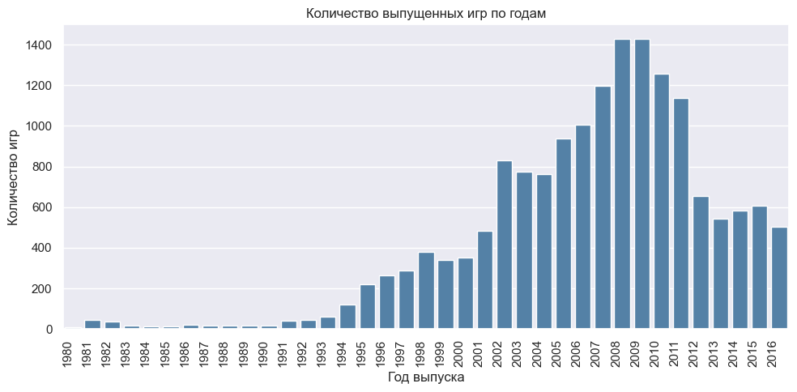

```python
# Данные
pivot_table = data.pivot_table(
    index='year_of_release', values='name', aggfunc='count')
# График
sns.set(style='darkgrid')
plt.figure(figsize=(10, 5))
ax = sns.barplot(x=pivot_table.index, y='name',
                 data=pivot_table, color='steelblue')
plt.title('Количество выпущенных игр по годам')
plt.xlabel('Год выпуска')
plt.ylabel('Количество игр')
ax.set_xticklabels(ax.get_xticklabels(), rotation=90, ha='right')
plt.tight_layout()
plt.show()
```

**Вывод:** Условно можно разделить на четыре периода: 1. до 1995 года, стабильное количество выпускаем игр 2. c 1995 года по 2009 год, резкий рост количества выпускаем игр 3. с 2009 по 2012 годы, резкое падение количества выпускаем игр 4. с 2012 года примерно стабильное количество выпускаемых игр Актуальными данными вероятно является последний период с 2013 года по настоящее время

## **Как менялись продажи по платформам во времени?**

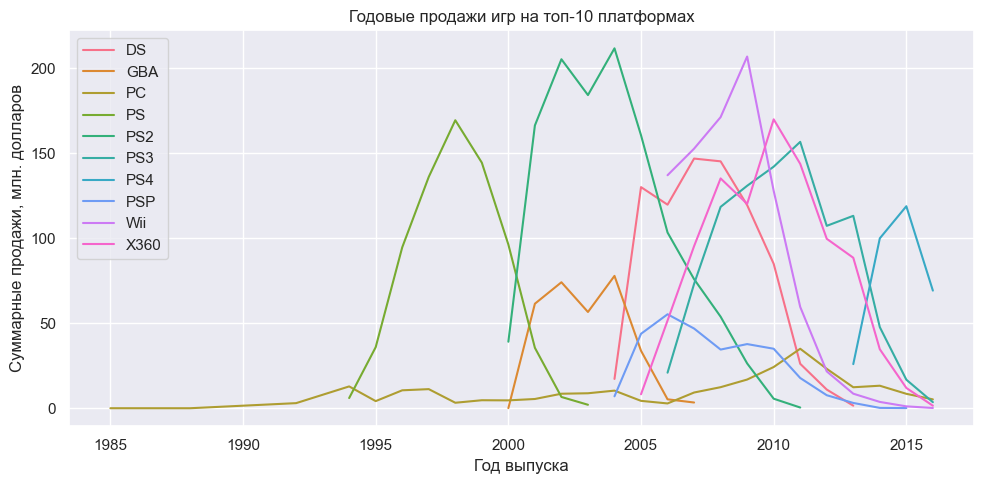

```python
# Создаю список топ10-платформ
top_platforms_index = data.pivot_table(index='platform', values='all_sales', aggfunc='sum').sort_values(
    by='all_sales', ascending=False).head(10).index

# Создание сводной таблицы суммарных продаж по годам и платформам с фильтрацией датасета по топ10 платформам
top_platforms = data[data['platform'].isin(top_platforms_index)].pivot_table(
    index='year_of_release', columns='platform', values='all_sales', aggfunc='sum')

# Создание графика
sns.set(style='darkgrid')
sns.set_palette('husl', n_colors=len(top_platforms.columns))
plt.figure(figsize=(10, 5))
for platform in top_platforms.columns:
    plt.plot(top_platforms.index, top_platforms[platform], label=platform)
plt.title('Годовые продажи игр на топ-10 платформах')
plt.legend(labels=top_platforms.columns)
plt.xlabel('Год выпуска')
plt.ylabel('Суммарные продажи, млн. долларов')
plt.tight_layout()
plt.show()
```

Анализирую время жизни платформы для поиска актуального периода

```python
# Построение сводной таблицы с началом релиза игр и концом релизов
life_lenght = data.pivot_table(
    index='platform', values='year_of_release', aggfunc=('max', 'min'))

# Длительность релизов в годах
life_lenght['lenght'] = life_lenght['max'] - life_lenght['min']

# Среднее и медиана
print('Медианная продолжительность жизни платформы',
      life_lenght['lenght'].median())
print('Средняя продолжительность жизни платформы',
      round(life_lenght['lenght'].mean(), 1))

# Считаю время жизни платформ из топ10, расчёт такой же как и выше
life_lenght_top = data[data['platform'].isin(top_platforms_index)].pivot_table(
    index='platform', values='year_of_release', aggfunc=('max', 'min'))
life_lenght_top['lenght'] = life_lenght_top['max'] - life_lenght_top['min']
print('Медианная продолжительность жизни платформы из топ-10',
      life_lenght_top['lenght'].median())
print('Средняя продолжительность жизни платформы из топ-10',
      life_lenght_top['lenght'].mean())
```

```
Медианная продолжительность жизни платформы 6.0
Средняя продолжительность жизни платформы 7.6
Медианная продолжительность жизни платформы из топ-10 10.5
Средняя продолжительность жизни платформы из топ-10 13.1
```

**Вывод**

- Время жизни платформы различно и составляет в среднем 7-13 лет, в медианных значениях 6-10 лет
- Время жизни зависит от успешности платформы в суммарных продажах
- Паттерн продаж в топ-10 схож среди платформ

## **Выбираю актуальные данные для дальнейшего анализа**

Актуальными данными считаю попадающими в период с 2013 год по н.в. (т.е. за три предыдущих года), исходя из времени жизни платформы и динамики общих продаж игр. Рост продаж и падение продаж происходят очень быстро, и актуальность платформы меняется буквально за пару-тройку лет

```python
# Новая переменная с актулальными данными
actual_platforms = ['3DS', 'PC', 'PS3', 'PS4', 'PSV', 'WiiU', 'XOne']
data_actual = data[(data['year_of_release'] >= 2013) &
                   (data['platform'].isin(actual_platforms))]
# display(data_actual)
```

## **Какие платформы лидируют по продажам, растут или падают?**

```python
# Сумма продаж за актуальный период
print('Сумма продаж за актуальный период')
display(data_actual.pivot_table(index='platform', values='all_sales',
        aggfunc='sum').sort_values(by='all_sales', ascending=False))

# Сводная таблица по продажам по годам/платформе за актуальный период
print('Сводная таблица по продажам по годам/платформе за актуальный период')
top_platforms_actual = data_actual.pivot_table(
    index='year_of_release', columns='platform', values='all_sales', aggfunc='sum')
display(top_platforms_actual)
```

```
Сумма продаж за актуальный период
```

| platform | all_sales |
| --- | --- |
| PS4 | 314.14 |
| PS3 | 181.43 |
| XOne | 159.32 |
| 3DS | 143.25 |
| WiiU | 64.63 |
| PC | 39.43 |
| PSV | 32.99 |

```
Сводная таблица по продажам по годам/платформе за актуальный период
```

| platform year_of_release | 3DS | PC | PS3 | PS4 | PSV | WiiU | XOne |
| --- | --- | --- | --- | --- | --- | --- | --- |
| 2013 | 56.57 | 12.38 | 113.25 | 25.99 | 10.59 | 21.65 | 18.96 |
| 2014 | 43.76 | 13.28 | 47.76 | 100.00 | 11.90 | 22.03 | 54.07 |
| 2015 | 27.78 | 8.52 | 16.82 | 118.90 | 6.25 | 16.35 | 60.14 |
| 2016 | 15.14 | 5.25 | 3.60 | 69.25 | 4.25 | 4.60 | 26.15 |

**Вывод**

## **Глобальным продажи игр в разбивке по платформам**

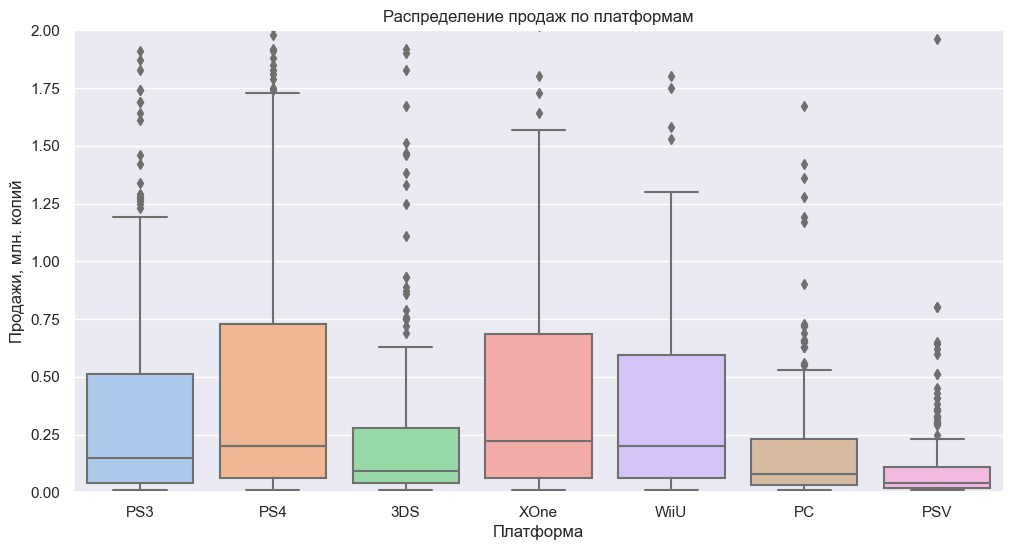

```python
plt.figure(figsize=(12, 6))
plt.ylim(0, 2)
sns.set_palette('pastel')
sns.boxplot(data=data_actual, x='platform', y='all_sales')
plt.title('Распределение продаж по платформам')
plt.xlabel('Платформа')
plt.ylabel('Продажи, млн. копий')
plt.show()
```

**Вывод**

Для актуальных платформ и уже утрачивающих актуальность сходная картина по продажам - 75% игр едва ли дотягивают до 750 тыс копий. Для 3DS, PC, PSV 75% игр продано в тираже до 250 тысяч копий.

Медиана (очень усредненно) для многих платформ находится в районе 200 тысяч копий проданных игр

Однако для каждой актуальной платформы есть немного крайне успешных игр, проданных от миллиона копий и до 20+ миллионов.

## **Взаимосвязь между оценками (игроки и критики) и общими продажами**

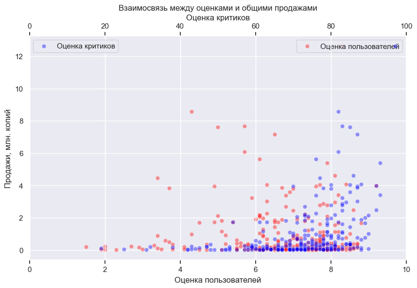

```python
# Создание отдельных осей для каждого графика
fig, ax1 = plt.subplots(figsize=(10, 6))
ax2 = ax1.twiny()

# График для оценок пользователей
sns.scatterplot(data=data_actual.loc[data['platform'] == 'PS4'], x='user_score', y='all_sales',
                alpha=0.4, ax=ax1, color='red', label='Оценка пользователей')

# График для оценок критиков
sns.scatterplot(data=data_actual.loc[data['platform'] == 'PS4'], x='critic_score',
                y='all_sales', alpha=0.4, ax=ax2, color='blue', label='Оценка критиков')

ax1.set_title(
    'Взаимосвязь между оценками и общими продажами')
ax1.set_xlabel('Оценка пользователей')
ax2.set_xlabel('Оценка критиков')
ax1.set_ylabel('Продажи, млн. копий')
ax1.set_xlim(0, 10)
ax2.set_xlim(0, 100)
handles, labels = ax1.get_legend_handles_labels()
ax1.legend(handles, labels, loc='upper right')
plt.show()
```

```python
# Корреляция между оценками пользователей и общими продажами
user_score_corr = data_actual.loc[data['platform'] == 'PS4']['all_sales'].corr(
    data_actual.loc[data['platform'] == 'PS4']['user_score'])
print('Корреляция между оценками пользователей и общими продажами:', user_score_corr)

# Корреляция между оценками критиков и общими продажами
critic_score_corr = data_actual.loc[data['platform'] == 'PS4']['all_sales'].corr(
    data_actual.loc[data['platform'] == 'PS4']['critic_score'])
print('Корреляция между оценками критиков и общими продажами:', critic_score_corr)
```

```
Корреляция между оценками пользователей и общими продажами: -0.03195711020455643
Корреляция между оценками критиков и общими продажами: 0.40656790206178123
```

**Вывод**

Корреляции между оценками пользователей и общими продажами для платформы PS4 нет. Существуте слабая корреляция между оценками критиков и общими продажами для платформы PS4. Оценка критиков более подходящая для оценки продаж.

**Соотнесите выводы с продажами игр на других платформах.**

```python
# Расчёт корреляции для продаж/оценок на других платформах

for i in data_actual['platform'].unique():
    corr = data_actual[data['platform'] == i]['all_sales'].corr(
        data_actual[data['platform'] == i]['user_score'])
    print(
        f'Корреляция между оценками пользователей и общими продажами для платформы {i} {corr:.1f}')

for i in data_actual['platform'].unique():
    corr = data_actual[data['platform'] == i]['all_sales'].corr(
        data_actual[data['platform'] == i]['critic_score'])
    print(
        f'Корреляция между оценками критиков и общими продажами для платформы {i} {corr:.1f}')
```

```
Корреляция между оценками пользователей и общими продажами для платформы PS3 0.0
Корреляция между оценками пользователей и общими продажами для платформы PS4 -0.0
Корреляция между оценками пользователей и общими продажами для платформы 3DS 0.2
Корреляция между оценками пользователей и общими продажами для платформы XOne -0.1
Корреляция между оценками пользователей и общими продажами для платформы WiiU 0.4
Корреляция между оценками пользователей и общими продажами для платформы PC -0.1
Корреляция между оценками пользователей и общими продажами для платформы PSV 0.0
Корреляция между оценками критиков и общими продажами для платформы PS3 0.3
Корреляция между оценками критиков и общими продажами для платформы PS4 0.4
```

```
Корреляция между оценками критиков и общими продажами для платформы 3DS 0.4
Корреляция между оценками критиков и общими продажами для платформы XOne 0.4
Корреляция между оценками критиков и общими продажами для платформы WiiU 0.4
Корреляция между оценками критиков и общими продажами для платформы PC 0.2
Корреляция между оценками критиков и общими продажами для платформы PSV 0.3
```

**Вывод**

В целом данные для корреляции по всем актуальным платформам соотносятся с оценкой пользователей/продажами, кроме платформы WiiU.

Для каждой платформы существует слабая корреляция между оценками критиков и продажами. Для некоторых платформ она выше, для некоторых ниже. Самая слабая корреляция для оценок игр на PC.

## **Какие жанры игр продаются больше всех? Выделяются ли жанры с высокими и низкими продажами?**

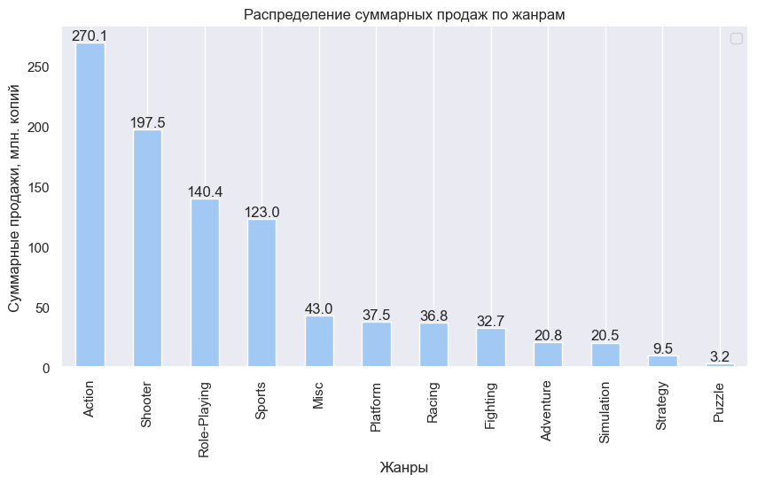

```python
# Создание сводной таблицы суммарных продаж по жанрам
genre_sales = data_actual.pivot_table(
    index='genre', values='all_sales', aggfunc='sum')
# Сортировка по убыванию
genre_sales_sorted = genre_sales.sort_values(by='all_sales', ascending=False)

# Создание графика
fig, ax = plt.subplots(figsize=(10, 5))
genre_sales_sorted.plot(kind='bar', ax=ax)

# Добавление подписей значений на столбцах
for i, value in enumerate(genre_sales_sorted['all_sales']):
    ax.text(i, value, f'{value:.1f}', ha='center', va='bottom')

# Настройка оформления графика
ax.set_title(
    'Распределение суммарных продаж по жанрам')
ax.set_xlabel('Жанры')
ax.set_ylabel('Суммарные продажи, млн. копий')
ax.legend('')
ax.grid(axis='y')

plt.show()
```

[output not shown]

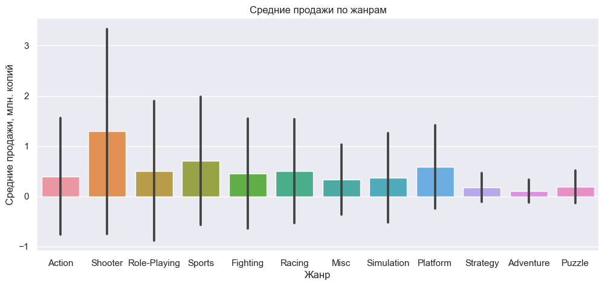

```python
# График средних продаж с ошибками
fig, ax = plt.subplots(figsize=(12, 5))
sns.set(style='darkgrid')
sns.barplot(data=data_actual, x='genre', y='all_sales', errorbar='sd', ax=ax)
ax.set_title('Средние продажи по жанрам')
ax.set_xlabel('Жанр')
ax.set_ylabel('Средние продажи, млн. копий')
plt.show
```

**Вывод**

Сказать о прибыльность сложно, так как не указана цена игр и цена разработки/маркетинга и прочего. Самые частопродающиеся жанры - Action, Shooter, Role-Playing, Sports. Самые малопродаваемые - Strategy, Puzzle.

В среднем по продажам игр на каждый жанр, наиболее продающиеся: Shooter (в среднем 1.29 млн копий), но с высоким стандартным отклонением; Sports (в среднем 0.7 млн копий), но с высоким стандартным отклонением.

В целом для каждого жанра характерно высокое стандартное отклонение, прогнозировать продажи по жанру - гадание

# Портрет пользователя каждого региона

Определите для пользователя каждого региона (NA, EU, JP)

## **Самые популярные платформы (топ-5)**

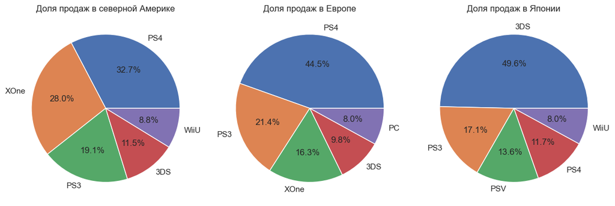

```python
fig, axes = plt.subplots(nrows=1, ncols=3, figsize=(12, 4))

region_title = ['Доля продаж в северной Америке',
                'Доля продаж в Европе', 'Доля продаж в Японии']

# Построение графиков для каждого региона
for i, region in enumerate(['na_sales', 'eu_sales', 'jp_sales']):
    # Получение данных по продажам и платформам
    sales_by_platform = (data_actual
                         .pivot_table(index='platform', values=region, aggfunc='sum')
                         .sort_values(by=region, ascending=False)
                         .head(5))
    ax = axes[i]
    ax.pie(sales_by_platform[region],
           labels=sales_by_platform.index, autopct='%1.1f%%')
    ax.set_title(region_title[i])

plt.tight_layout()
plt.show()
```

**Вывод**

Продажи на платформах сильно зависят от региона. В целом регионы EU и NA схожи по продажам по платформам.

1. Для североамериаканского рынка наиболее востребованы (за четыре прошедших года) **PS4, XOne (занимают больше половины рынка)**.
2. Для европейского рынка наиболее востребованы (за четыре прошедших года) **PS4 (почти половина рынка), на втором месте PS3**.
3. Для японского рынка наиболее востребованы (за четыре прошедших года) **3DS (половина рынка), остальные платформы в равной степени делят рынок**.

## **Самые популярные жанры (топ-5)**

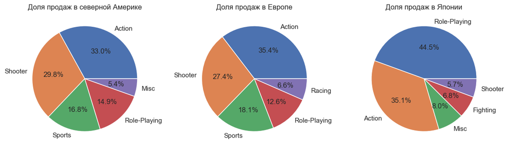

```python
# Строю диаграммы pie для каждого региона по продажам по жанрам
fig, axes = plt.subplots(nrows=1, ncols=3, figsize=(12, 4))

region_title = ['Доля продаж в северной Америке',
                'Доля продаж в Европе', 'Доля продаж в Японии']

# Построение графиков для каждого региона
for i, region in enumerate(['na_sales', 'eu_sales', 'jp_sales']):
    # Получение данных по продажам и платформам
    sales_by_platform = (data_actual
                         .pivot_table(index='genre', values=region, aggfunc='sum')
                         .sort_values(by=region, ascending=False)
                         .head(5))
    ax = axes[i]
    ax.pie(sales_by_platform[region],
           labels=sales_by_platform.index, autopct='%1.1f%%')
    ax.set_title(region_title[i])

plt.tight_layout()
plt.show()
```

**Вывод**

Продажи игр различных жанров сильно зависят от региона. Однако регионы EU и NA очень схожи.

1. Для североамериаканского рынка наиболее востребованы жанры (за четыре прошедших года) **Action, shooter, sports**.
2. Для европейского рынка наиболее востребованы жанры (за четыре прошедших года) **Action, shooter, sports**.
3. Для японского рынка наиболее востребованы жанры (за четыре прошедших года) **Action и Role-playing**.